# Data Mining lezione 2

Optimism and Information Criteria

Valerio Calà

17/10/2019

## 1. Optimism

L’ottimismo (**Opt**) è definito come la differenza attesa tra il Mean Squared Error del test set e quello del training set.  
Si tratta di una quantità informativa dell’over-ottimismo dovuto alla stima sul training set (che avrà sempre errore inferiore rispetto al test) e permette di calcolare il forecast error (*valore atteso del test error*) come somma tra l’errore nel training set e l’ottimismo.

$$\begin{aligned}
\mathrm{Opt} &= \mathbb{E}(\mathrm{MSE}_{\mathrm{Te}}) - \mathbb{E}(\mathrm{MSE}_{\mathrm{Tr}})
\end{aligned}$$

$$\begin{aligned}
\widehat{\mathrm{ErrF}} &= \mathrm{MSE}_{\mathrm{Tr}} + \mathrm{OptF}\\
\end{aligned}$$

In generale si può dimostrare che l’Opt è pari alla media del doppio della covarianza tra il processo stocastico Y ed i suoi valori fittati:
$$\mathrm{OptF} = \frac{2}{n}\sum_{i=1}^{n}\mathbb{C}\mathrm{ov}(y_i,\hat{f}(x_i))$$

Per modelli lineari si dimostra che l’Opt è pari a $\frac{2\sigma^2 p}{n}$, però è poco realistico assumere che la vera varianza del processo stocastico è nota. Per questo motivo si rimpiazza la quantità incognita ($\sigma^2$) con la sua stima campionaria:

$$\hat{\sigma}^2= \frac{\mathrm{RSS}}{n-p}= \frac{\sum_{i=1}^{n}( y_i - \hat{f}(x_i))^2}{n-p}$$

Lo stimatore del forecast error per modelli lineari, con l’Opt stimato attraverso la varianza campionaria, si chiama **CP di Mallow** e nel caso di *Fixed-X* setting è pari a:

$$\mathrm{Cp} = \mathrm{MSE}_{\mathrm{Tr}} + \frac{2 \hat{\sigma}^2 p}{n} = \frac{\mathrm{RSS}}{n}(1+ \frac{2p}{n-p})$$
N.B. $\mathrm{p}$ è il numero di parametri da stimare nel modello lineare, **intercetta inclusa**

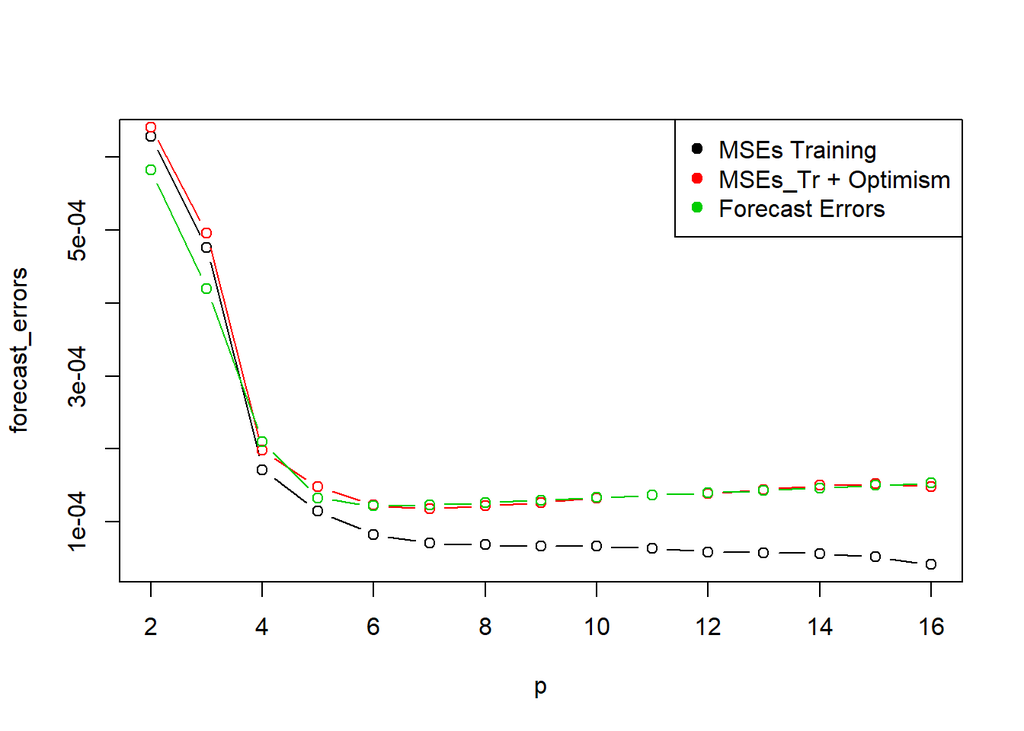

```r
# dgp : Y = f(x) + error
# caso: sigma noto

ftrue <- c(0.4342,0.4780,0.5072,0.5258,0.5369,0.5426,0.5447,0.5444,0.5425,0.5397,0.5364,0.5329,0.5294,0.5260,0.5229,0.5200,0.5174,0.5151,0.5131,0.5113,0.5097,0.5083,0.5071,0.5061,0.5052,0.5044,0.5037,0.5032,0.5027,0.5023)

x <- seq(0.5, 3, length=30)

n <- length(x)
sigma <- 0.01

set.seed(123)

y <- ftrue + rnorm(n, 0, sigma)

fun <- function(d) {
   fit <- lm(y ~ poly(x, degree=d))
}

# calcolo dell'Opt per d=1,2,...,15
ds <- 1:15
ps <- ds + 1
fits <- lapply(ds, fun)

MSEs <- unlist(lapply(fits, deviance))/n
RSSs <- n*MSEs

Opts <- 2*sigma^2*ps/n

Vars <- sigma^2*ps/n

Bias2 <- sapply(ds, function(d)
  mean( ( ftrue - fitted(lm(ftrue ~ poly(x, degree=d))) )^2 )
  )

# calcolo del Forecast Error per d=1,2,..,15
forecast_errors <- Bias2 + Vars + sigma^2

# stima del Forecast Error per d=1,2,...,15
ErrF <- MSEs + Opts

# plot degli errori
plot(ps, MSEs, type="b", xlab="p", ylab="forecast_errors")
lines(ps, ErrF, type="b", col=2)
lines(ps, forecast_errors, type="b", col=3)
legend("topright", c("MSEs Training","MSEs_Tr + Optimism", "Forecast Errors"), col=c(1,2,3), pch=19)
```

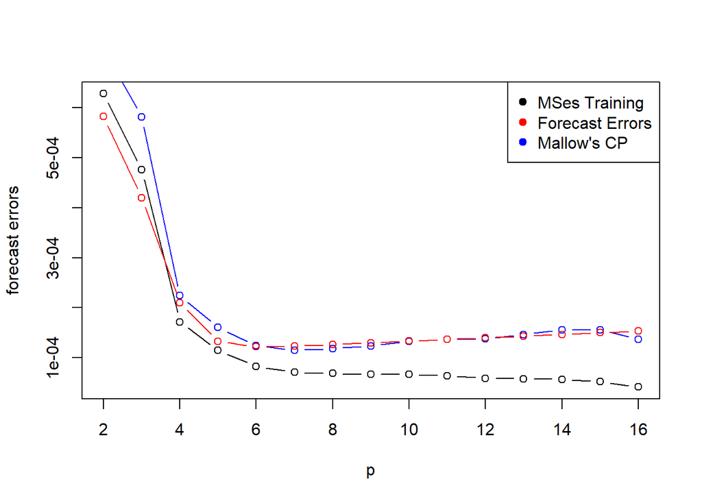

```r
# stima del Mallow's CP
# caso: sigma INCOGNITO

hat_sigma2 <- n*MSEs/(n - ps)
hat_Opts <- 2*hat_sigma2*ps/n
CP <- MSEs + hat_Opts

plot(ps, MSEs, type="b", xlab="p", ylab="forecast errors")
lines(ps, CP, type="b", col=4)
lines(ps, forecast_errors, type="b", col=2)
legend("topright", c("MSes Training", "Forecast Errors", "Mallow's CP"), col=c(1,2,4), pch=19)
```

## 2. Information Criteria

Si tratta di altri criteri (alternativi al forecast error e al Mallow’s CP) per decidere il miglior modello tra i vari addestrati. Ci muoviamo quindi ancora nell’ambito *model selection* e presentiamo i seguenti criteri informativi:

1. **AIC** : *Akaike Information Criteria*

$$\mathrm{AIC} = -2 \cdot \mathrm{loglikelihood}(\hat{\beta},\hat{\sigma}^2) + 2p$$

2. **BIC** : *Bayesian Information Criteria*

$$\mathrm{BIC} = -2 \cdot \mathrm{loglikelihood}(\hat{\beta},\hat{\sigma}^2) + \log(n)p$$

Poiché log(n) > 2 per ogni n>7, il BIC assume valori più grandi dell’AIC e tende a selezionare modelli più parsimoniosi in termini di numero di predictors utilizzati rispetto all’AIC.

**Solo per i modelli lineari** si dimostra che l’AIC è proporzionale al Mean Squared Error del training set:
$$-2 \cdot \mathrm{loglikelihood}(\hat{\beta},\hat{\sigma}^2) = n \log(\mathrm{MSE}_{\mathrm{Tr}})$$
Di conseguenza, è proporzionale anche al Mallow’s CP: quindi con i modelli lineari i due criteri diventano equivalenti, perché verranno minimizzati in corrispondenza dello stesso modello.

Si conclude la lezione con un confronto grafico di AIC e BIC per i dati già presentati.

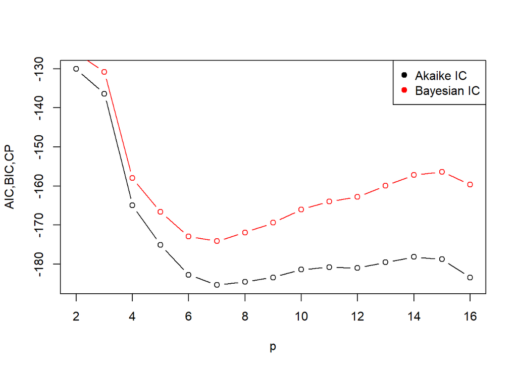

```r
AICs <- unlist(lapply(fits, AIC))
BICs <- unlist(lapply(fits, BIC))

plot(ps, AICs, type="b", xlab="p", ylab="AIC,BIC,CP")
lines(ps, BICs, type="b", col=2)

legend("topright", c("Akaike IC","Bayesian IC"), col=c(1,2), pch=19)
```

Best model secondo entrambi i criteri: p=7 -> polinomio di grado d=6  
N.B. viene selezionato lo stesso modello anche secondo il Mallow’s CP.

## 3. Random-X setting

Fin’ora abbiamo affrontato il caso *Fixed-X* in cui i regressori X erano variabili deterministiche.  
Adesso affrontiamo il caso più realistico di variabili esplicative (sia nel training che nel test) stocastiche e vediamo come cambiano i risultati già visti.

La coppia di v.aleatorie $(X,Y)$ ha una distribuzione congiunta incognita: l’obiettivo rimane trovare una stima della relazione tra Y ed X ‘fatta bene’ (cioè con basso bias e bassa varianza, i.e. basso errore riducibile).  
Condizionatamente ad $X=x$ (realizzazioni delle variabili esplicative) la variabile target Y è pari alla funzione di regressione $f(X)$ + l’errore irriducibile $\varepsilon$ (*noise*).

$$f(x) = \mathbb{E}(Y|X=x)$$
Il problema di stima si può formulare in termini di ottimizzazione: l’obiettivo è trovare una funzione $g()$ che sia ‘vicina’ alla vera funzione $f()$, dove ‘vicino’ significa che lo scarto quadratico è minimo. Il problema di minimizzazione in modo formale è il seguente:
$$f = \underset{g}{\arg\min} \,\, \mathbb{E}_{X,Y}[(Y - g(X))^2]$$

La soluzione è il previsore ottimo:
$$f(X) = \mathbb{E}(Y|X)$$

Si dimostra che questa è la soluzione del *minimization problem* prendendo il condizionamento a $X=x$ ed applicando la legge del valore atteso iterato:
$$\mathbb{E}_{X,Y}\{[Y - g(X)]^2\} = \mathbb{E}_X \mathbb{E}_{Y|X=x} \{[Y - g(x)]^2 | X=x\}$$

Il problema si ‘riduce’ quindi ad una minimizzazione punto-a-punto:
$$f(x) =\underset{c}{\arg\min} \,\, \mathbb{E}_{Y|X=x} \{[Y - c ]^2 | X=x\}$$

Aggiungo e sottraggo la soluzione e riscrivo la funzione obiettivo sfruttando le proprietà dell’operatore valore atteso $\mathbb{E}$. Si dimsotra così facilmente che la soluzione è la media condizionata e che questa è la miglior previsione per $Y$ dato $X=x$.

$$f(x) = \mathbb{E}(Y|X=x)$$

Vediamo quindi in questo *Random-X* setting come cambiano le formule per calcolare l’Ottimismo e l’Errore di Previsione.

Se **assumiamo una distribuzione congiunta Gaussiana**, allora il previsore ottimo coincide con il previsore lineare e l’ottimismo diventa

$$Opt.Random = Opt.Fixed + \frac{\sigma^2p}{n}\left( \frac{p+1}{n-p-1}\right) = \frac{\sigma^2p}{n}\left(2 + \frac{p+1}{n-p-1}\right)$$

Si può quindi stimare il *Forecast Error* sommando all’Opt.Random l’MSE nel training set.

Se la vera varianza del processo non è nota (come in molte *real-world applications*) allora sostituiamo $\sigma^2$ con la sua stima $\hat\sigma^2=RSS/(n-p)$ ed otteniamo il Mallow’s CP in *Random-X* setting:

$$\mathrm{RCp} = \mathrm{Cp} + \frac{\hat{\sigma}^2p}{n}\left( \frac{p+1}{n-p-1}\right) = \frac{\mathrm{RSS}(n-1)}{(n-p)(n-p-1)}$$